# Find connections between clusters.

Quentin Goss `quentingoss0323@floridapoly.edu`

Florida Polytechnic University `COP5090.01`

05 November 2018

PREVIOUS

# Introduction

On this page we will be finding connections between clustered regions. For the examples on this page we will be using the project `leopard` since the amount of points is visually fitting and sized nicely for the base R plots. We are going to need a coordinate matrix of the `leopard` project which we will get with the help of the script `clusterSUMO.project.R`.

```r
source(file='../scripts/clusterSUMO.project.R')
```

We start by performing k-means clustering on our `leopard` project. We use the `plot.kmeans` method from our script `clusterSUMO.project.R` to visualize our k-means clustered set of points and also to retrieve our cluster data which we put into the R object `coords.clusters`.

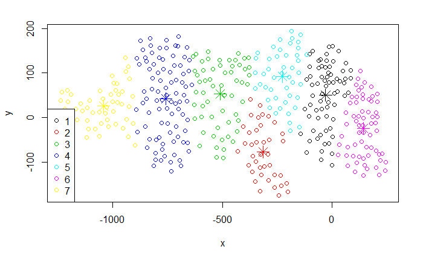

```r
coords.clusters <- plot.kmeans(project.name2cm('leopard'),k=7,return.cc=T)
```

We take a look at our `coords.clusters` dataframe.

```r
print(coords.clusters)
```

[output not shown]

[output cut: 19 more lines]

In our `coords.clusters` data frame, we are given the location of the cluster means.

```r
print(coords.clusters$centers)
```

```
            x         y
1   -29.64588  50.33779
2  -314.17667 -77.50359
3  -510.66224  52.96362
4  -758.84273  41.96261
5  -226.34478  92.71261
6   143.18984 -24.56969
7 -1042.40837  26.24510
```

We can plot the centers now too.

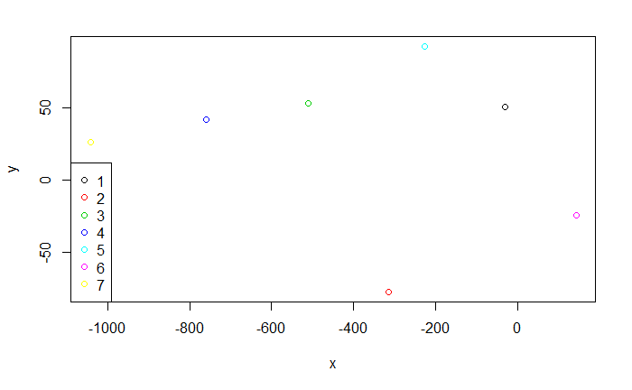

```r
k <- nrow(coords.clusters$centers)
plot(coords.clusters$centers,col=1:k)
legend(
  'bottomleft',
  pch = rep(1,k),
  legend = 1:k,
  col = unique(1:k)
)
```

Now we want to know how each cluster connects to one another. To do this, we’ll need our junction and edge data which we can retrieve with the help of the script `sumo_dg_viewer.R` which is loaded along with `clusterSUMO.project.R`.

```r
jmem <- json2matrices('leopard')
junctions.matrix <- jmem[[1]]
edges.matrix <- jmem[[2]]
# Clean up temporary object
rm(jmem)
print(head(junctions.matrix,n=5L))
```

```
        true_center_coords normal_center_coords
gneJ10  Numeric,2          Numeric,2
gneJ100 Numeric,2          Numeric,2
gneJ101 Numeric,2          Numeric,2
gneJ103 Numeric,2          Numeric,2
gneJ104 Numeric,2          Numeric,2
```

```r
print(head(edges.matrix,n=5L))
```

```
                   true_coords normal_coords from      to
gneJ3_to_gneJ2     Numeric,4   Numeric,4     "gneJ3"   "gneJ2"
gneJ99_to_gneJ88   Numeric,4   Numeric,4     "gneJ99"  "gneJ88"
gneJ100_to_gneJ99  Numeric,4   Numeric,4     "gneJ100" "gneJ99"
gneJ101_to_gneJ100 Numeric,4   Numeric,4     "gneJ101" "gneJ100"
gneJ104_to_gneJ103 Numeric,4   Numeric,4     "gneJ104" "gneJ103"
```

To view the simplified network, we initialize an empty adjacency matrix to store our connection data in.

```r
adjacency.matrix <- matrix(
  data = rep(0,k * k),
  nrow = k,
  ncol = k
)
rownames(adjacency.matrix) <- paste0('cluster_',1:k)
colnames(adjacency.matrix) <- paste0('cluster_',1:k)
print(adjacency.matrix)
```

```
          cluster_1 cluster_2 cluster_3 cluster_4 cluster_5 cluster_6 cluster_7
cluster_1         0         0         0         0         0         0         0
cluster_2         0         0         0         0         0         0         0
cluster_3         0         0         0         0         0         0         0
cluster_4         0         0         0         0         0         0         0
cluster_5         0         0         0         0         0         0         0
cluster_6         0         0         0         0         0         0         0
cluster_7         0         0         0         0         0         0         0
```

Then we go to each of our edges one by one and note which cluster they begin in and which cluster they end in. I.e. if we have a node `node.from.1` which is in cluster 3 and `node.to.5` we’ll increment the value of the adjency matrix at `row = cluster_3` and `column = cluster_5`.

```r
for (i in 1:nrow(edges.matrix)){
  # From
  node.from <- edges.matrix[[i,'from']]
  node.from.cluster <- coords.clusters$cluster[node.from]

  # To
  node.to <- edges.matrix[[i,'to']]
  node.to.cluster <- coords.clusters$cluster[node.to]

  # Update adjacency table
  if (node.to.cluster != node.from.cluster){
    adjacency.matrix[node.from.cluster,node.to.cluster] <- adjacency.matrix[node.from.cluster,node.to.cluster] + 1
  }
}
print(adjacency.matrix)
```

```
          cluster_1 cluster_2 cluster_3 cluster_4 cluster_5 cluster_6 cluster_7
cluster_1         0         1         0         0         7        11         0
cluster_2         1         0         6         0         5         0         0
cluster_3         0         6         0         9         5         0         0
cluster_4         0         0         9         0         0         0         9
cluster_5         7         5         5         0         0         0         0
cluster_6        11         0         0         0         0         0         0
cluster_7         0         0         0         9         0         0         0
```

Now we view the directed graph.

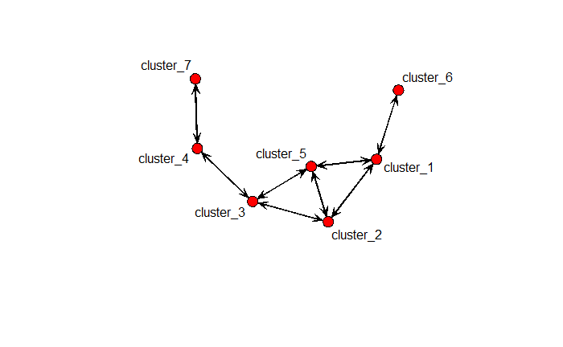

```r
adjacency.network <- network(
  adjacency.matrix,
  matrix.type="adjacency",
  directed=FALSE,
  cignore.eval=FALSE,
  names.eval="value"
)
gplot(
  adjacency.network,
  gmode="digraph",
  label=adjacency.network%v%'vertex.names',
  arrowhead.cex=1
)
```